# RNAseq_target_validation

KRG

7/30/2020

## Select Ago1 targets for ovary-expressed miRNAs

input file “Table_S5_ext.txt” is available as a zip file in my [Github](https://github.com/kathrynrozengagnon/AGOCLIP_2020)

```r
all_with_pats <- read.delim("/Users/kathryn/Reprocess_all_paper_datasets/Mol_cell_resub/Revision_files/Supplementary_Tables/Table_S5_ext.txt", header = TRUE, sep="\t", stringsAsFactors = FALSE)

all_merge_aegypti_Ago1 <- subset(all_with_pats, all_with_pats$aegypti_Ago1_BCsample > 0)
aegypti_Ago1_3UTR <- all_merge_aegypti_Ago1[grepl( "3' UTR", all_merge_aegypti_Ago1$annotation),]
```

## Select miRNAs

used Table S18 and S19 from [Akbari et al., 2013](https://www.ncbi.nlm.nih.gov/pmc/articles/PMC3755910/)

```r
#miRNAs that are high in the ovaries (>5000 RPM) and rare in the carcass (<1000 RPM)

##miR989
all_3UTR_989 <- rbind(aegypti_Ago1_3UTR[grepl("miR-989x", aegypti_Ago1_3UTR$aegyptiAgo1_chimera),], aegypti_Ago1_3UTR[grepl("miR-989", aegypti_Ago1_3UTR$PsmallRNA_family),])

##miR996
all_3UTR_996 <- rbind(aegypti_Ago1_3UTR[grepl("miR-996x", aegypti_Ago1_3UTR$aegyptiAgo1_chimera),], aegypti_Ago1_3UTR[grepl("miR-996", aegypti_Ago1_3UTR$PsmallRNA_family),])

##miR2946
all_3UTR_2946 <- rbind(aegypti_Ago1_3UTR[grepl("miR-2946x", aegypti_Ago1_3UTR$aegyptiAgo1_chimera),], aegypti_Ago1_3UTR[grepl("miR-2941", aegypti_Ago1_3UTR$PsmallRNA_family),]) #2946 shares seed with 2941, family name is 2941

##also select control miRNAs that are rare in the ovaries (<1000 RPM) and high in the carcass (>4000 RPM)

##miR981
all_3UTR_981 <- rbind(aegypti_Ago1_3UTR[grepl("miR-981x", aegypti_Ago1_3UTR$aegyptiAgo1_chimera),], aegypti_Ago1_3UTR[grepl("miR-981", aegypti_Ago1_3UTR$PsmallRNA_family),])

##miR7
all_3UTR_7<- rbind(aegypti_Ago1_3UTR[grepl("miR-7x", aegypti_Ago1_3UTR$aegyptiAgo1_chimera),], aegypti_Ago1_3UTR[grepl("miR-7", aegypti_Ago1_3UTR$PsmallRNA_family),])
#need to remove 79/71
all_3UTR_7 <- all_3UTR_7[!grepl("aae-miR-71", all_3UTR_7$PsmallRNA_family),]
all_3UTR_7 <- all_3UTR_7[!grepl("aae-miR-79", all_3UTR_7$PsmallRNA_family),]

##277 is high in the head, maybe can see that in brain or other head tissues - just for reviewer
all_3UTR_277<- rbind(aegypti_Ago1_3UTR[grepl("miR-277-3px", aegypti_Ago1_3UTR$aegyptiAgo1_chimera),], aegypti_Ago1_3UTR[grepl("miR-277-3p", aegypti_Ago1_3UTR$PsmallRNA_family),])
all_3UTR_277 <- all_3UTR_277[,c("geneId", "transcriptId")]
all_3UTR_277 <- unique(all_3UTR_277)


#write out gene names
h <-grep("all_3UTR",names(.GlobalEnv),value=TRUE)
h<- do.call("list",mget(h))

h <- lapply(h, function(x) x[,c("geneId", "transcriptId")])
hu <- lapply(h, unique)

#run this to write out gene lists:
# for(i in seq_along(hu)) {
#   write.table(hu[i], paste0("/Users/kathryn/Reprocess_all_paper_datasets/RNAseq_test/Ago1_lists_FINAL/", names(hu)[i], ".txt"),
#               col.names = TRUE, row.names = FALSE, sep = "\t", quote = FALSE)
# }

#write.table(all_3UTR_277, "/Users/kathryn/Reprocess_all_paper_datasets/RNAseq_test/Ago1_lists_FINAL/all_3UTR_277.txt", col.names = TRUE, row.names = FALSE, sep = "\t", quote = FALSE)
```

Ago1 miRNA target gene lists “all_3UTR_2946.txt”,“all_3UTR_7.txt”, “all_3UTR_981.txt”, “all_3UTR_989.txt”, “all_3UTR_996.txt” are available in my [Github](https://github.com/kathrynrozengagnon/AGOCLIP_2020/tree/master/Ago1_lists_FINAL) in the folder “Ago1_lists_FINAL”

## Get Ovary high and low genes as controls

Data were obtained from Table S6 from [Matthews et al., 2016](https://pubmed.ncbi.nlm.nih.gov/26738925/)  
Alternatively, you can access the file “Matthews_S6.txt” with RNAseq TPM for all tissues on my [Github](https://github.com/kathrynrozengagnon/AGOCLIP_2020/tree/master/Matthews_2016_data)

```r
diff_genes <- read.delim("/Users/kathryn/Reprocess_all_paper_datasets/RNAseq_test/Matthews_S6.txt", header = TRUE, sep = "\t")

Fe_Ov_all <- grep("Fe_Ov", colnames(diff_genes), value = TRUE)
Fe_all <- grep("Fe", colnames(diff_genes), value = TRUE)

diff_genes$Ov_av_all <- rowMeans(diff_genes[Fe_Ov_all])
diff_genes$all_Fe_notOv <- rowMeans(diff_genes[Fe_all])

diff_genes$Ov_hi <- diff_genes$Ov_av_all/diff_genes$all_Fe
diff_genes$Ov_lo <- diff_genes$all_Fe/diff_genes$Ov_av_all

Ov_hi <- diff_genes %>% top_n(50 , Ov_hi) %>% dplyr::select(gene)
Ov_lo <- diff_genes %>% top_n(-50 , Ov_hi) %>% dplyr::select(gene)

h <-grep("Ov",names(.GlobalEnv),value=TRUE)
h <- grep("lo|hi", h, value = TRUE)
h<- do.call("list",mget(h))
hu <- lapply(h, unique)
#for(i in seq_along(hu)) {
#  write.table(hu[i], #paste0("/Users/kathryn/Reprocess_all_paper_datasets/RNAseq_test/Ago1_lists_FI#NAL/", names(hu)[i], ".txt"),
#              col.names = TRUE, row.names = FALSE, sep = "\t", quote = FALSE)
#}
```

Control gene lists “Ov_hi2.txt” and “Ov_lo2.txt” are available in my [Github](https://github.com/kathrynrozengagnon/AGOCLIP_2020/tree/master/Ago1_lists_FINAL) in the folder “Ago1_lists_FINAL”

## GSVA for Ago1 ovary-specific miRNA targets (Figure S7C)

Input files are available for download from the [Vosshall lab Github](https://github.com/VosshallLab/Aedes_neurotranscriptome) associated with the Matthews et al., 2016 paper  
Alternatively, you can go to my Github to access [all the necessary data](https://github.com/kathrynrozengagnon/AGOCLIP_2020/tree/master/Matthews_2016_data)

```r
PECounts <- read.delim("/Users/kathryn/Reprocess_all_paper_datasets/RNAseq_test/Aedes_neurotranscriptome-home-newDESEQ2/raw_gene_counts/PE_featurecounts.txt",sep = "\t",skip=1)
SECounts <- read.delim("/Users/kathryn/Reprocess_all_paper_datasets/RNAseq_test/Aedes_neurotranscriptome-home-newDESEQ2/raw_gene_counts/SE_featurecounts.txt",sep = "\t",skip=1)
PECounts2 <- PECounts[,grepl("bam",colnames(PECounts))] %>% as.matrix %>% set_colnames(gsub("_\\..*","",colnames(.))) %>% set_rownames(PECounts$Geneid)
SECounts2 <- SECounts[,grepl("bam",colnames(SECounts))] %>% as.matrix %>% set_colnames(gsub("_merged.bam|bams\\.|Aligned.*|_SE","",colnames(.))) %>% set_rownames(SECounts$Geneid)
annotation <- read.delim("/Users/kathryn/Reprocess_all_paper_datasets/RNAseq_test/Aedes_neurotranscriptome-home-newDESEQ2/annotations/annotation_with_orthodb-20150730.csv",sep=",")

myAgo1List <- dir("/Users/kathryn/Reprocess_all_paper_datasets/RNAseq_test/Ago1_lists_FINAL/",full.names = TRUE) %>% lapply(function(x)read.delim(x,header=TRUE)[,1] %>% as.vector)

#map to their geneIDs
Ago1setList <- lapply(myAgo1List,function(x) unique(annotation[annotation[,2] %in% x,1]) %>% na.omit %>% as.vector)
names(Ago1setList) <- dir("/Users/kathryn/Reprocess_all_paper_datasets/RNAseq_test/Ago1_lists_FINAL/") %>% gsub("\\.txt","",.)

SECounts2 <- SECounts2[,!colnames(SECounts2) %in% c("Fe_An_BF_1","Fe_An_SF_5")]
myNewCounts <- merge(SECounts2,PECounts2,by=0)

myNewCounts <- myNewCounts[,!colnames(myNewCounts) %in% "Fe_Br_SF_2"]
metaData<- data.frame(Group=gsub("_\\d$","",colnames(myNewCounts)),row.names = colnames(myNewCounts))
metaData2 <- data.frame(Group=gsub("_\\d$","",colnames(myNewCounts)),
                        Paired=ifelse(colnames(myNewCounts) %in% colnames(PECounts2),"Paired","Single"),
                        row.names = colnames(myNewCounts))

myNewCounts2 <- myNewCounts[,-1]
rownames(myNewCounts2) <- myNewCounts[,1]
myCounts2 <- edgeR::cpm(myNewCounts2)
require(GSVA)

Fe <- grep("Fe", colnames(myCounts2), value = TRUE)
mhCountsAgo1 <- gsva(myCounts2[,colnames(myCounts2) %in% Fe],gset.idx.list = Ago1setList[grepl("UTR|Ov", names(Ago1setList))],kcdf=c("Poisson"))
```

```
## Estimating GSVA scores for 8 gene sets.
## Computing observed enrichment scores
## Estimating ECDFs with Poisson kernels
## Using parallel with 12 cores
##
```

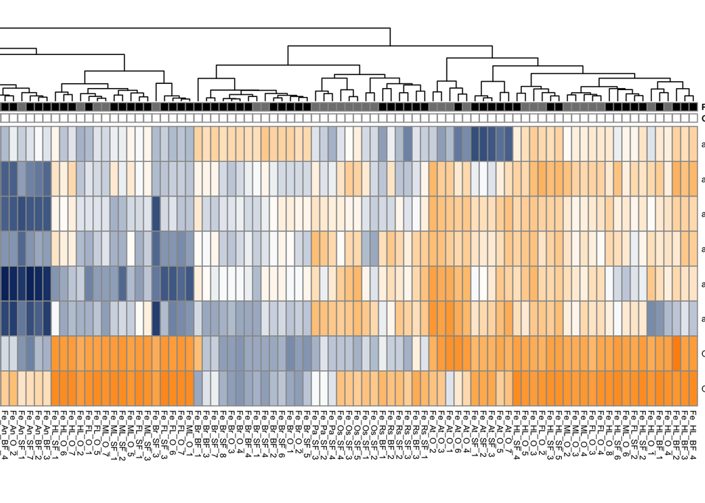

```r
#visualize with heatmap
colors <- metaData2
colors <- as.data.frame(unique(colors$Group))
colors <- setNames(colors, c("Group"))
colors$color <- ifelse(grepl("Ov_O", colors$Group), paste0("lightslateblue"), paste0(colors$color))
colors$color <- ifelse(grepl("Ov_SF", colors$Group), paste0("plum"), paste0(colors$color))
mycolors <- as.character(colors$color)
names(mycolors) <- colors$Group
mycolors <- list(Group = mycolors)
mycolors$Paired <- c("gray50", "black")
names(mycolors$Paired) <- c("Paired", "Single")

paletteLength <- 50
palAgo1 <- colorRampPalette(c( "#08306B","white", "darkorange"))(paletteLength)
myBreaks <- c(seq(min(mhCountsAgo1), 0, length.out=ceiling(paletteLength/2) + 1), seq(max(mhCountsAgo1)/paletteLength, max(mhCountsAgo1), length.out=floor(paletteLength/2)))

pheatmap:::pheatmap(mhCountsAgo1,
                    annotation_col = metaData2,
                     color = palAgo1, breaks = myBreaks,
                    cluster_cols = TRUE,cluster_rows = TRUE, scale="none", fontsize_col = 6, annotation_colors = mycolors, treeheight_row = 20, fontsize = 6, cellheight = 25, cellwidth = 6)
```

## eCDFs of miRNA target expression, Figures 7A-7C, S7A and S7B

Need to normalize by transcript length for this analysis, use gtf with Matthews et al. gene IDs As above, input files are available for download from the [Vosshall lab Github](https://github.com/VosshallLab/Aedes_neurotranscriptome) associated with the Matthews et al., 2016 paper  
Alternatively, you can go to my Github to access [all the necessary data](https://github.com/kathrynrozengagnon/AGOCLIP_2020/tree/master/Matthews_2016_data)

```r
gtffile <- "/Users/kathryn/Reprocess_all_paper_datasets/RNAseq_test/Aedes_neurotranscriptome-home-newDESEQ2/annotations/STAR_featureCount.gtf"

TxDb <- makeTxDbFromGFF(gtffile)
```

```
## Import genomic features from the file as a GRanges object ... OK
## Prepare the 'metadata' data frame ... OK
## Make the TxDb object ... OK
```

```r
myLens <- transcriptLengths(TxDb) %>% group_by(gene_id) %>% summarise(gene_len=median(tx_len))

myNewCounts3 <- merge(myNewCounts2, myLens, by.x=0, by.y= "gene_id", all.x=TRUE)
row.names(myNewCounts3) <- myNewCounts3$Row.names

d <- DGEList(counts = myNewCounts3[,c(2:130)])
d$genes$Length <- c(myNewCounts3$gene_len)
myCountstest <- edgeR::rpkm(d)
myCountstest <- as.data.frame(myCountstest)


Fe_all <- grep("Fe", colnames(myCountstest), value = TRUE)
Fe_Ov <- grep("Ov", colnames(myCountstest), value = TRUE)
Fe_Ov_SF <- grep("SF", Fe_Ov, value = TRUE)
Fe_Ov_O <- grep("SF", Fe_Ov, value = TRUE, invert = TRUE)

myCountstest$Fe_Ov_SF_av <- rowMeans(myCountstest[Fe_Ov_SF])
myCountstest$Fe_Ov_O_av <- rowMeans(myCountstest[Fe_Ov_O])
myCountstest$Fe_mean <- rowMeans(myCountstest[Fe_all])

#high in ovary miRNAs
##miR-989
test989 <- myCountstest[row.names(myCountstest) %in% Ago1setList$all_3UTR_989,]
test989<- test989[grepl("mean|av", colnames(test989))]
test989<- melt(test989)
```

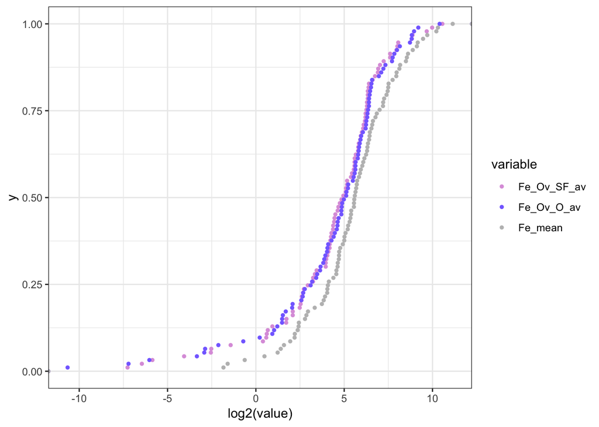

```r
ggplot(test989, aes(log2(value), colour = variable)) + stat_ecdf(geom = "point", size=1) + scale_colour_manual(values=c("plum", "lightslateblue","gray")) + theme_bw()
```

```r
wilcox.test(subset(test989$value, test989$variable=="Fe_Ov_O_av") , subset(test989$value, test989$variable=="Fe_mean"),
            alternative = c("l"))
```

```
##
##  Wilcoxon rank sum test with continuity correction
##
## data:  subset(test989$value, test989$variable == "Fe_Ov_O_av") and subset(test989$value, test989$variable == "Fe_mean")
## W = 3675.5, p-value = 0.02335
## alternative hypothesis: true location shift is less than 0
```

```r
wilcox.test(subset(test989$value, test989$variable=="Fe_Ov_SF_av") , subset(test989$value, test989$variable=="Fe_mean"),
            alternative = c("l"))
```

```
##
##  Wilcoxon rank sum test with continuity correction
##
## data:  subset(test989$value, test989$variable == "Fe_Ov_SF_av") and subset(test989$value, test989$variable == "Fe_mean")
## W = 3585.5, p-value = 0.01287
## alternative hypothesis: true location shift is less than 0
```

```r
##miR-996
test996 <- myCountstest[row.names(myCountstest) %in% Ago1setList$all_3UTR_996,]
test996<- test996[grepl("mean|av", colnames(test996))]
test996<- melt(test996)
```

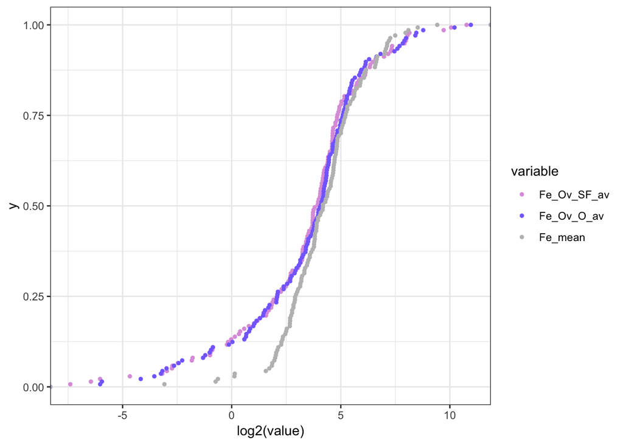

```r
ggplot(test996, aes(log2(value), colour = variable)) + stat_ecdf(geom = "point", size=1) + scale_colour_manual(values=c("plum", "lightslateblue","gray")) + theme_bw()
```

```r
wilcox.test(subset(test996$value, test996$variable=="Fe_Ov_O_av") , subset(test996$value, test996$variable=="Fe_mean"),
            alternative = c("l"))
```

```
##
##  Wilcoxon rank sum test with continuity correction
##
## data:  subset(test996$value, test996$variable == "Fe_Ov_O_av") and subset(test996$value, test996$variable == "Fe_mean")
## W = 8334, p-value = 0.05469
## alternative hypothesis: true location shift is less than 0
```

```r
wilcox.test(subset(test996$value, test996$variable=="Fe_Ov_SF_av") , subset(test996$value, test996$variable=="Fe_mean"),
            alternative = c("l"))
```

```
##
##  Wilcoxon rank sum test with continuity correction
##
## data:  subset(test996$value, test996$variable == "Fe_Ov_SF_av") and subset(test996$value, test996$variable == "Fe_mean")
## W = 8082, p-value = 0.02356
## alternative hypothesis: true location shift is less than 0
```

```r
##miR-2946
test2946 <- myCountstest[row.names(myCountstest) %in% Ago1setList$all_3UTR_2946,]
test2946<- test2946[grepl("mean|av", colnames(test2946))]
test2946<- melt(test2946)
```

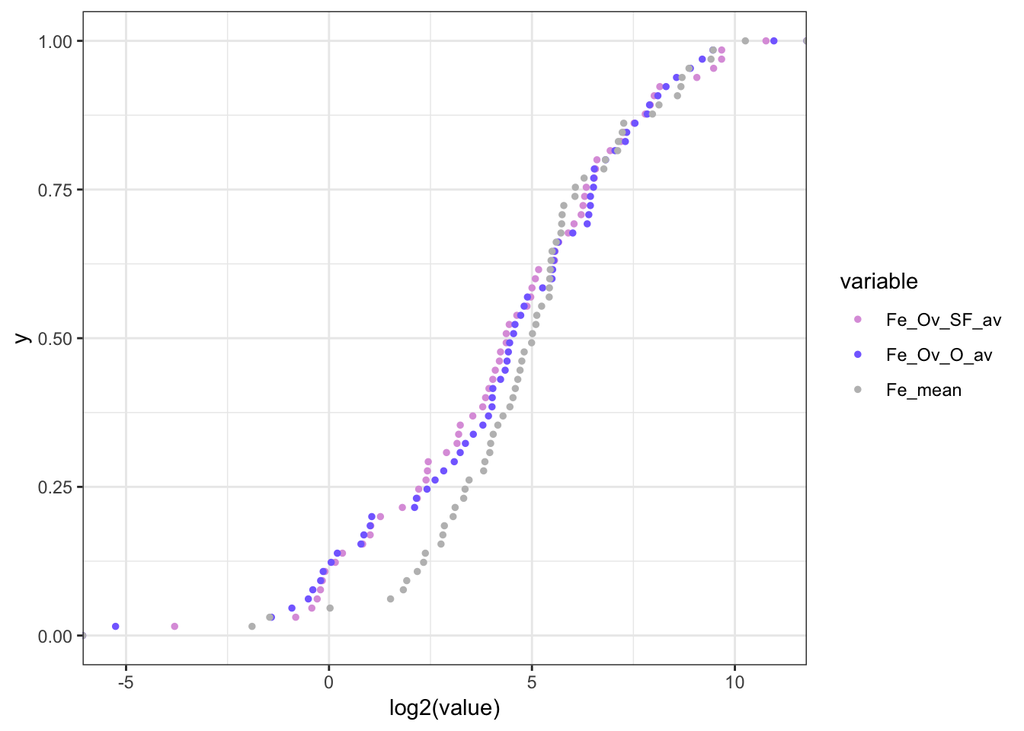

```r
ggplot(test2946, aes(log2(value), colour = variable)) + stat_ecdf(geom = "point", size=1) + scale_colour_manual(values=c("plum", "lightslateblue","gray")) + theme_bw()
```

```r
wilcox.test(subset(test2946$value, test2946$variable=="Fe_Ov_O_av") , subset(test2946$value, test2946$variable=="Fe_mean"),
            alternative = c("l"))
```

```
##
##  Wilcoxon rank sum test with continuity correction
##
## data:  subset(test2946$value, test2946$variable == "Fe_Ov_O_av") and subset(test2946$value, test2946$variable == "Fe_mean")
## W = 2008.5, p-value = 0.2209
## alternative hypothesis: true location shift is less than 0
```

```r
wilcox.test(subset(test2946$value, test2946$variable=="Fe_Ov_SF_av") , subset(test2946$value, test2946$variable=="Fe_mean"),
            alternative = c("l"))
```

```
##
##  Wilcoxon rank sum test with continuity correction
##
## data:  subset(test2946$value, test2946$variable == "Fe_Ov_SF_av") and subset(test2946$value, test2946$variable == "Fe_mean")
## W = 1948.5, p-value = 0.1487
## alternative hypothesis: true location shift is less than 0
```

```r
###control miRNAs (low in ovary)
##miR-7
test7 <- myCountstest[row.names(myCountstest) %in% Ago1setList$all_3UTR_7,]
test7<- test7[grepl("mean|av", colnames(test7))]
test7<- melt(test7)
```

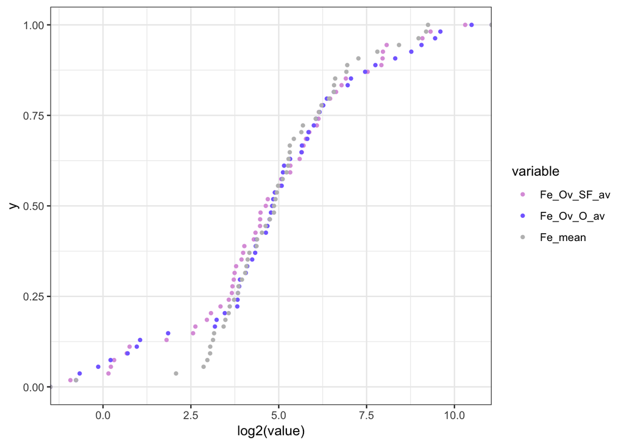

```r
ggplot(test7, aes(log2(value), colour = variable)) + stat_ecdf(geom = "point", size=1) + scale_colour_manual(values=c("plum", "lightslateblue","gray")) + theme_bw()
```

```r
wilcox.test(subset(test7$value, test7$variable=="Fe_Ov_O_av"), subset(test7$value, test7$variable=="Fe_mean"), alternative = c("l"))
```

```
##
##  Wilcoxon rank sum test with continuity correction
##
## data:  subset(test7$value, test7$variable == "Fe_Ov_O_av") and subset(test7$value, test7$variable == "Fe_mean")
## W = 1514.5, p-value = 0.506
## alternative hypothesis: true location shift is less than 0
```

```r
wilcox.test(subset(test7$value, test7$variable=="Fe_Ov_SF_av"), subset(test7$value, test7$variable=="Fe_mean"), alternative = c("l"))
```

```
##
##  Wilcoxon rank sum test with continuity correction
##
## data:  subset(test7$value, test7$variable == "Fe_Ov_SF_av") and subset(test7$value, test7$variable == "Fe_mean")
## W = 1458.5, p-value = 0.3745
## alternative hypothesis: true location shift is less than 0
```

```r
#miR-981
test981 <- myCountstest[row.names(myCountstest) %in% Ago1setList$all_3UTR_981,]
test981<- test981[grepl("mean|av", colnames(test981))]
test981<- melt(test981)
```

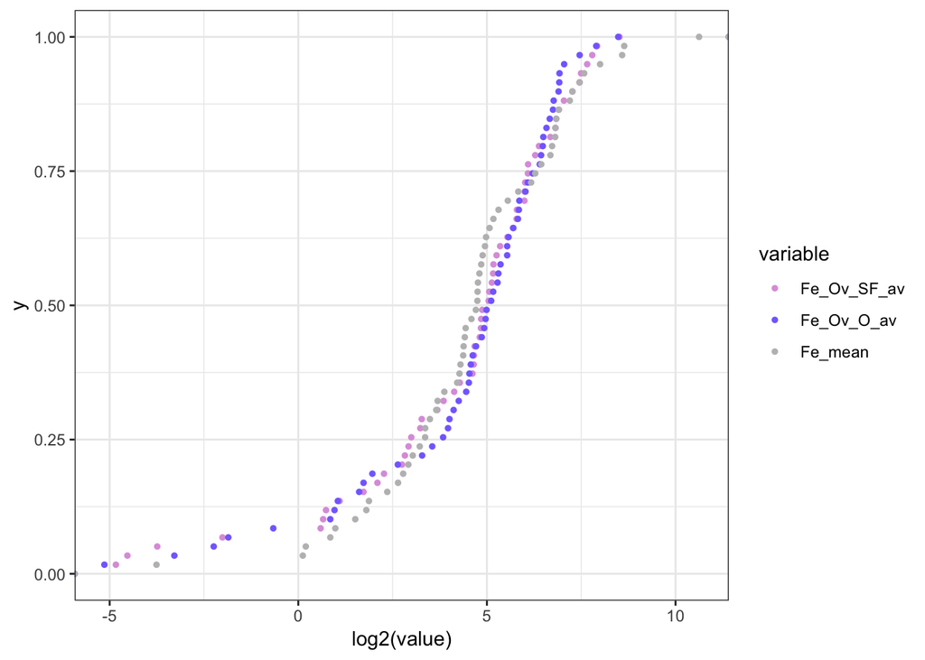

```r
ggplot(test981, aes(log2(value), colour = variable)) + stat_ecdf(geom = "point", size=1) + scale_colour_manual(values=c("plum", "lightslateblue","gray")) + theme_bw()
```

```r
wilcox.test(subset(test981$value, test981$variable=="Fe_Ov_O_av"), subset(test981$value, test981$variable=="Fe_mean"), alternative = c("l"))
```

```
##
##  Wilcoxon rank sum test with continuity correction
##
## data:  subset(test981$value, test981$variable == "Fe_Ov_O_av") and subset(test981$value, test981$variable == "Fe_mean")
## W = 1821, p-value = 0.6686
## alternative hypothesis: true location shift is less than 0
```

```r
wilcox.test(subset(test981$value, test981$variable=="Fe_Ov_SF_av"), subset(test981$value, test981$variable=="Fe_mean"), alternative = c("l"))
```

```
##
##  Wilcoxon rank sum test with continuity correction
##
## data:  subset(test981$value, test981$variable == "Fe_Ov_SF_av") and subset(test981$value, test981$variable == "Fe_mean")
## W = 1789, p-value = 0.604
## alternative hypothesis: true location shift is less than 0
```

## Select Ago2 targets for ovary-expressed esiRNAs

input files “all_putative_known_sRNA_seeds2.txt” (generated in *mirdeep2_processing_filtering* script), “Table_S4.txt” and “all_Ago2_known_novel_fam_rn.fa” (generated in *smallRNA_abundance_scatterplots* script) are available in my [Github](https://github.com/kathrynrozengagnon/AGOCLIP_2020)

```r
#get 3'UTRs and Ago2-supported peaks
all_merge_aegypti_Ago2 <- subset(all_with_pats, all_with_pats$aegypti_Ago2_BCsample > 0)
aegypti_Ago2_3UTR <- all_merge_aegypti_Ago2[grepl( "3' UTR", all_merge_aegypti_Ago2$annotation),]

#perfect targets (all, doesn't need to be 3'UTR)
aegypti_perf <- all_merge_aegypti_Ago2[grepl("novel|aae", all_merge_aegypti_Ago2$Pperfect_18mer_target),]
aegypti_perf <- aegypti_perf[grepl("common-AGO2|aegypti-AGO2", aegypti_perf$Pperfect_18mer_target),]

#chimera 3'UTR targets
aegypti_chim_Ago2 <- aegypti_Ago2_3UTR[grepl("AGO2_both|AGO2_aegypti", aegypti_Ago2_3UTR$top_smallRNA_chimera),]
aegypti_chim_Ago2 <- aegypti_chim_Ago2[!aegypti_chim_Ago2$peakID %in% aegypti_perf$peakID,]

#6mer 3'UTR targets
aegypti_6mer_Ago2 <- aegypti_Ago2_3UTR[grepl("AGO2_both|AGO2_aegypti", aegypti_Ago2_3UTR$Ptop_smallRNA),]
aegypti_6mer_Ago2_no_chim  <- aegypti_6mer_Ago2[!aegypti_6mer_Ago2$peakID %in% aegypti_perf$peakID,]
aegypti_6mer_Ago2_no_chim  <- aegypti_6mer_Ago2_no_chim [!aegypti_6mer_Ago2_no_chim $peakID %in% aegypti_chim_Ago2$peakID,]

#8mer targets
seed_table <- read.delim("/Users/kathryn/Reprocess_all_paper_datasets/Supp_Figs/all_putative_known_sRNA_seeds.txt", header = TRUE, sep ="\t", stringsAsFactors = FALSE) #913 unique seed combos
seeds_df <- read.delim("/Users/kathryn/Reprocess_all_paper_datasets/Mol_cell_resub/Revision_files/Supplementary_Tables/Table_S4.txt", sep = "\t", header = TRUE, stringsAsFactors = FALSE)

#link to small RNA names
seed_table <- merge(seeds_df[,c(1:2, 38)], seed_table,by.x = "smallRNA_sequence" , by.y = "FL", all.x= TRUE )

#select top most abundant/targeting esiRNAs
Ago2_sRNAs <- readDNAStringSet("/Users/kathryn/Reprocess_all_paper_datasets/Rmds_to_upload/To_upload/all_Ago2_known_novel_fam_rn.fa", format = "fasta")
Ago2_sRNAs_aegypti <- Ago2_sRNAs[grepl("common-Ago2|aegypti-Ago2|aae-miR", names(Ago2_sRNAs))]

seed_table$filt <- seed_table$six_mer_target %in% Ago2_sRNAs_aegypti
Ago2_top_seeds <- subset(seed_table, seed_table$filt==TRUE)

#make vector of top Ago2 esiRNA names to search in 8mer column
vec8 <- as.character(Ago2_top_seeds$smallRNA)
vec8 <- gsub("AGO1", "Ago1", vec8)
vec8 <- gsub("AGO2", "Ago2", vec8)

row.names(aegypti_6mer_Ago2_no_chim) <- 1:nrow(aegypti_6mer_Ago2_no_chim)

matmatch8 <- vector("list", length(vec8))
for (i in 1:length(vec8)) {
  matmatch8[[i]] <- aegypti_6mer_Ago2_no_chim[grepl(vec8[i], aegypti_6mer_Ago2_no_chim$Peight_target),]
  matmatch8[[i]] <- matmatch8[[i]]$peakID
}

matmatch8 <- unique(unlist(matmatch8))
aegypti_Ago2_8 <- aegypti_6mer_Ago2_no_chim[aegypti_6mer_Ago2_no_chim$peakID %in% matmatch8,]
#have already removed perfect and chimera

##alt 8
matmatch8alt <- vector("list", length(vec8))
for (i in 1:length(vec8)) {
  matmatch8alt[[i]] <- aegypti_6mer_Ago2_no_chim[grepl(vec8[i], aegypti_6mer_Ago2_no_chim$Peight_target_alt),]
  matmatch8alt[[i]] <- matmatch8alt[[i]]$peakID
}

matmatch8alt <- unique(unlist(matmatch8alt))
aegypti_Ago2_8alt <- aegypti_6mer_Ago2_no_chim[aegypti_6mer_Ago2_no_chim$peakID %in% matmatch8alt,]

#remove 8mers from 6mer no chim
aegypti_6mer_Ago2_no_chim_no8 <- aegypti_6mer_Ago2_no_chim[!aegypti_6mer_Ago2_no_chim$peakID %in% aegypti_Ago2_8alt$peakID,]
aegypti_6mer_Ago2_no_chim_no8 <- aegypti_6mer_Ago2_no_chim_no8[!aegypti_6mer_Ago2_no_chim_no8$peakID %in% aegypti_Ago2_8$peakID,]


#get non_3UTR
aegypti_Ago2_non3UTR <- all_merge_aegypti_Ago2[!grepl( "3' UTR", all_merge_aegypti_Ago2$annotation),]
#is mutually exclusive with 6mers because they have to be in 3UTR, same for chimera
aegypti_Ago2_non3UTR <- aegypti_Ago2_non3UTR[!aegypti_Ago2_non3UTR$peakID %in% aegypti_perf$peakID,]
aegypti_Ago2_non3UTRtop <- aegypti_Ago2_non3UTR[grepl("AGO2_both|AGO2_aegypti", aegypti_Ago2_non3UTR$Ptop_smallRNA) ,]

tosel <- c("aegypti_Ago2_non3UTRtop", "aegypti_Ago2_8alt", "aegypti_Ago2_8", "aegypti_chim_Ago2", "aegypti_perf", "aegypti_6mer_Ago2_no_chim_no8" )


h<- do.call("list",mget(tosel))
h <- lapply(h, function(x) x[,c("geneId", "transcriptId")])
hu <- lapply(h, unique)
names(hu) <- names(h)


#for(i in seq_along(hu)) {
#  write.table(hu[i], paste0("/Users/kathryn/Reprocess_all_paper_datasets/RNAseq_test/Ago2_lists_FINAL/", names(hu)[i], ".txt"),
#              col.names = TRUE, row.names = FALSE, sep = "\t", quote = FALSE)
#}
```

Ago2 esiRNA target gene lists are available in my [Github](https://github.com/kathrynrozengagnon/AGOCLIP_2020/tree/master/Ago2_lists_FINAL) in the folder “Ago2_lists_FINAL”

## GSVA for Ago2, Figure S7D

```r
myAgo2List <- dir("/Users/kathryn/Reprocess_all_paper_datasets/RNAseq_test/Ago2_lists_FINAL/",full.names = TRUE) %>% lapply(function(x)read.delim(x,header=TRUE)[,1] %>% as.vector)

#map to their geneIDs
Ago2setList <- lapply(myAgo2List,function(x) unique(annotation[annotation[,2] %in% x,1]) %>% na.omit %>% as.vector)
names(Ago2setList) <- dir("/Users/kathryn/Reprocess_all_paper_datasets/RNAseq_test/Ago2_lists_FINAL/") %>% gsub("\\.txt","",.)

removetarg <- unlist(Ago2setList)
names(removetarg) <- NULL
nottarg <- row.names(myNewCounts2)[!row.names(myNewCounts2) %in% removetarg]
Ago2setList$nontarget <- nottarg

Ago2setList$all8 <- unique(c(Ago2setList$aegypti_Ago2_8alt, Ago2setList$aegypti_Ago2_8))

mhCountsAgo2 <- gsva(myCounts2[,colnames(myCounts2) %in% Fe],gset.idx.list = Ago2setList[!grepl("aegypti_Ago2_8alt|aegypti_Ago2_8", names(Ago2setList))],kcdf=c("Poisson"))
```

```
## Estimating GSVA scores for 6 gene sets.
## Computing observed enrichment scores
## Estimating ECDFs with Poisson kernels
## Using parallel with 12 cores
##
```

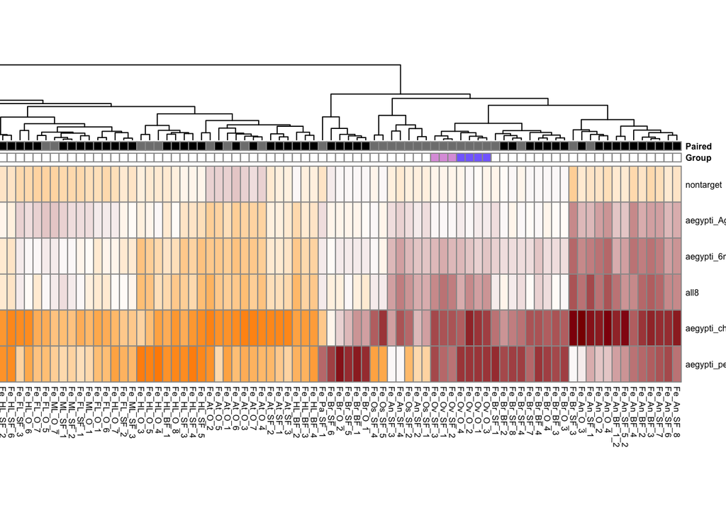

```r
#visualize with heatmap
colors <- metaData2
colors <- as.data.frame(unique(colors$Group))
colors <- setNames(colors, c("Group"))
colors$color <- ifelse(grepl("Ov_O", colors$Group), paste0("lightslateblue"), paste0(colors$color))
colors$color <- ifelse(grepl("Ov_SF", colors$Group), paste0("plum"), paste0(colors$color))
mycolors <- as.character(colors$color)
names(mycolors) <- colors$Group
mycolors <- list(Group = mycolors)
mycolors$Paired <- c("gray50", "black")
names(mycolors$Paired) <- c("Paired", "Single")

paletteLength <- 50
palAgo2 <- colorRampPalette(c("darkred", "white", "darkorange"))(paletteLength)
myBreaks <- c(seq(min(mhCountsAgo2), 0, length.out=ceiling(paletteLength/2) + 1), seq(max(mhCountsAgo2)/paletteLength, max(mhCountsAgo2), length.out=floor(paletteLength/2)))


pheatmap:::pheatmap(mhCountsAgo2,
                    annotation_col = metaData2,
                     color = palAgo2, breaks = myBreaks,
                    cluster_cols = TRUE,cluster_rows = TRUE, scale="none", fontsize_col = 6, annotation_colors = mycolors, treeheight_row = 20, fontsize = 6, cellheight = 25, cellwidth = 6)
```

## Ago2 eCDF, Figures 7E and 7F

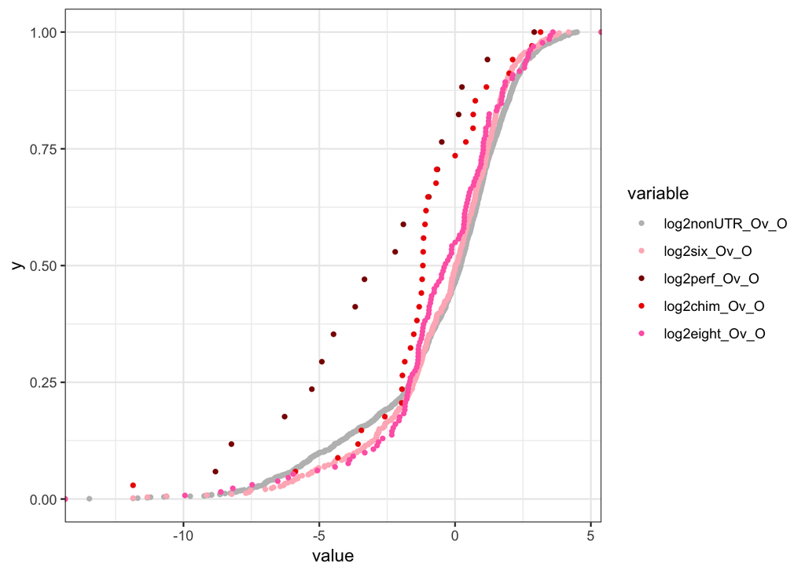

```r
#calculate log2FC of all tissues versus ovary, because see expression in the ovary of esiRNAs
myCountstest$gene <- row.names(myCountstest)
perf_cdf <- myCountstest[row.names(myCountstest) %in% Ago2setList$aegypti_perf,]
perf_cdf<- perf_cdf[grepl("av|mean|gene", colnames(perf_cdf))]
perf_cdf$log2perf_Ov_SF <- log2(perf_cdf$Fe_Ov_SF_av) - log2(perf_cdf$Fe_mean)
perf_cdf$log2perf_Ov_O <- log2(perf_cdf$Fe_Ov_O_av) - log2(perf_cdf$Fe_mean)
perf_cdf <- melt(perf_cdf, id.vars = c("gene"), measure.vars = c("log2perf_Ov_SF", "log2perf_Ov_O"))

six_cdf <- myCountstest[row.names(myCountstest) %in% Ago2setList$aegypti_6mer_Ago2_no_chim_no8,]
six_cdf <- six_cdf[grepl("av|mean|gene", colnames(six_cdf))]
six_cdf$log2six_Ov_SF <- log2(six_cdf$Fe_Ov_SF_av) - log2(six_cdf$Fe_mean)
six_cdf$log2six_Ov_O <- log2(six_cdf$Fe_Ov_O_av) - log2(six_cdf$Fe_mean)
six_cdf <- melt(six_cdf, id.vars = c("gene"), measure.vars = c("log2six_Ov_SF", "log2six_Ov_O"))

eight_cdf <- myCountstest[row.names(myCountstest) %in% Ago2setList$all8,]
eight_cdf <- eight_cdf[grepl("av|mean|gene", colnames(eight_cdf))]
eight_cdf$log2eight_Ov_SF <- log2(eight_cdf$Fe_Ov_SF_av) - log2(eight_cdf$Fe_mean)
eight_cdf$log2eight_Ov_O <- log2(eight_cdf$Fe_Ov_O_av) - log2(eight_cdf$Fe_mean)
eight_cdf <- melt(eight_cdf, id.vars = c("gene"), measure.vars = c("log2eight_Ov_SF", "log2eight_Ov_O"))

chim_cdf <- myCountstest[row.names(myCountstest) %in% Ago2setList$aegypti_chim_Ago2,]
chim_cdf <- chim_cdf[grepl("av|mean|gene", colnames(chim_cdf))]
chim_cdf$log2chim_Ov_SF <- log2(chim_cdf$Fe_Ov_SF_av) - log2(chim_cdf$Fe_mean)
chim_cdf$log2chim_Ov_O <- log2(chim_cdf$Fe_Ov_O_av) - log2(chim_cdf$Fe_mean)
chim_cdf <- melt(chim_cdf, id.vars = c("gene"), measure.vars = c("log2chim_Ov_SF", "log2chim_Ov_O"))

nonUTR_cdf <- myCountstest[row.names(myCountstest) %in% Ago2setList$aegypti_Ago2_non3UTRtop,]
nonUTR_cdf <- nonUTR_cdf[grepl("av|mean|gene", colnames(nonUTR_cdf))]
nonUTR_cdf$log2nonUTR_Ov_SF <- log2(nonUTR_cdf$Fe_Ov_SF_av) - log2(nonUTR_cdf$Fe_mean)
nonUTR_cdf$log2nonUTR_Ov_O <- log2(nonUTR_cdf$Fe_Ov_O_av) - log2(nonUTR_cdf$Fe_mean)
nonUTR_cdf <- melt(nonUTR_cdf, id.vars = c("gene"), measure.vars = c("log2nonUTR_Ov_SF", "log2nonUTR_Ov_O"))

Ago2_cdf <- rbind(nonUTR_cdf, six_cdf, perf_cdf, chim_cdf, eight_cdf )


ggplot(Ago2_cdf[grepl("Ov_O", Ago2_cdf$variable),], aes(value, colour = variable)) + stat_ecdf(geom = "point", size=1) + scale_colour_manual(values=c("gray","lightpink", "red4", "red2", "hotpink")) + theme_bw()
```

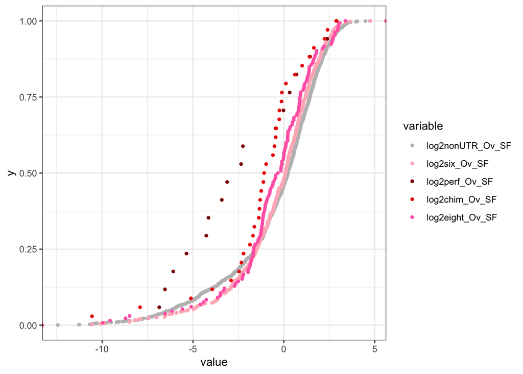

```r
ggplot(Ago2_cdf[grepl("Ov_SF", Ago2_cdf$variable),], aes(value, colour = variable)) + stat_ecdf(geom = "point", size=1) + scale_colour_manual(values=c("gray","lightpink", "red4", "red2", "hotpink" )) + theme_bw()
```

```r
wilcox.test(subset(Ago2_cdf$value,Ago2_cdf$variable=="log2perf_Ov_SF"), subset(Ago2_cdf$value, Ago2_cdf$variable=="log2nonUTR_Ov_SF"),alternative = c("l")) #0.01023
```

```
##
##  Wilcoxon rank sum test with continuity correction
##
## data:  subset(Ago2_cdf$value, Ago2_cdf$variable == "log2perf_Ov_SF") and subset(Ago2_cdf$value, Ago2_cdf$variable == "log2nonUTR_Ov_SF")
## W = 8730, p-value = 0.01023
## alternative hypothesis: true location shift is less than 0
```

```r
wilcox.test(subset(Ago2_cdf$value,Ago2_cdf$variable=="log2six_Ov_SF"), subset(Ago2_cdf$value, Ago2_cdf$variable=="log2nonUTR_Ov_SF"),alternative = c("l")) #0.1747
```

```
##
##  Wilcoxon rank sum test with continuity correction
##
## data:  subset(Ago2_cdf$value, Ago2_cdf$variable == "log2six_Ov_SF") and subset(Ago2_cdf$value, Ago2_cdf$variable == "log2nonUTR_Ov_SF")
## W = 355650, p-value = 0.1747
## alternative hypothesis: true location shift is less than 0
```

```r
wilcox.test(subset(Ago2_cdf$value,Ago2_cdf$variable=="log2eight_Ov_SF"), subset(Ago2_cdf$value, Ago2_cdf$variable=="log2nonUTR_Ov_SF"),alternative = c("l")) #0.03799
```

```
##
##  Wilcoxon rank sum test with continuity correction
##
## data:  subset(Ago2_cdf$value, Ago2_cdf$variable == "log2eight_Ov_SF") and subset(Ago2_cdf$value, Ago2_cdf$variable == "log2nonUTR_Ov_SF")
## W = 91291, p-value = 0.03799
## alternative hypothesis: true location shift is less than 0
```

```r
wilcox.test(subset(Ago2_cdf$value,Ago2_cdf$variable=="log2chim_Ov_SF"), subset(Ago2_cdf$value, Ago2_cdf$variable=="log2nonUTR_Ov_SF"),alternative = c("l")) #0.00934
```

```
##
##  Wilcoxon rank sum test with continuity correction
##
## data:  subset(Ago2_cdf$value, Ago2_cdf$variable == "log2chim_Ov_SF") and subset(Ago2_cdf$value, Ago2_cdf$variable == "log2nonUTR_Ov_SF")
## W = 19818, p-value = 0.00934
## alternative hypothesis: true location shift is less than 0
```

```r
wilcox.test(subset(Ago2_cdf$value,Ago2_cdf$variable=="log2perf_Ov_O"), subset(Ago2_cdf$value, Ago2_cdf$variable=="log2nonUTR_Ov_O"),alternative = c("l")) #0.001305
```

```
##
##  Wilcoxon rank sum test with continuity correction
##
## data:  subset(Ago2_cdf$value, Ago2_cdf$variable == "log2perf_Ov_O") and subset(Ago2_cdf$value, Ago2_cdf$variable == "log2nonUTR_Ov_O")
## W = 7451, p-value = 0.001305
## alternative hypothesis: true location shift is less than 0
```

```r
wilcox.test(subset(Ago2_cdf$value,Ago2_cdf$variable=="log2six_Ov_O"), subset(Ago2_cdf$value, Ago2_cdf$variable=="log2nonUTR_Ov_O"),alternative = c("l")) #0.2492
```

```
##
##  Wilcoxon rank sum test with continuity correction
##
## data:  subset(Ago2_cdf$value, Ago2_cdf$variable == "log2six_Ov_O") and subset(Ago2_cdf$value, Ago2_cdf$variable == "log2nonUTR_Ov_O")
## W = 357800, p-value = 0.2492
## alternative hypothesis: true location shift is less than 0
```

```r
wilcox.test(subset(Ago2_cdf$value,Ago2_cdf$variable=="log2eight_Ov_O"), subset(Ago2_cdf$value, Ago2_cdf$variable=="log2nonUTR_Ov_O"),alternative = c("l")) # 0.1278
```

```
##
##  Wilcoxon rank sum test with continuity correction
##
## data:  subset(Ago2_cdf$value, Ago2_cdf$variable == "log2eight_Ov_O") and subset(Ago2_cdf$value, Ago2_cdf$variable == "log2nonUTR_Ov_O")
## W = 93730, p-value = 0.1278
## alternative hypothesis: true location shift is less than 0
```

```r
wilcox.test(subset(Ago2_cdf$value,Ago2_cdf$variable=="log2chim_Ov_O"), subset(Ago2_cdf$value, Ago2_cdf$variable=="log2nonUTR_Ov_O"),alternative = c("l")) #0.01105
```

```
##
##  Wilcoxon rank sum test with continuity correction
##
## data:  subset(Ago2_cdf$value, Ago2_cdf$variable == "log2chim_Ov_O") and subset(Ago2_cdf$value, Ago2_cdf$variable == "log2nonUTR_Ov_O")
## W = 19944, p-value = 0.01105
## alternative hypothesis: true location shift is less than 0
```